```python
import numpy as np
import matplotlib.pyplot as plt
from IPython.display import display, Image
from PIL import Image as PILImage
from io import BytesIO

def notebook_dp_image(path: str, dim: set) -> None:
    img = PILImage.open(path)
    resized_img = img.resize(dim)  # (Width, Height)
    buffer = BytesIO()
    resized_img.save(buffer, format='PNG')
    display(Image(data=buffer.getvalue()))
```

*p261~308까지*

# 딥러닝

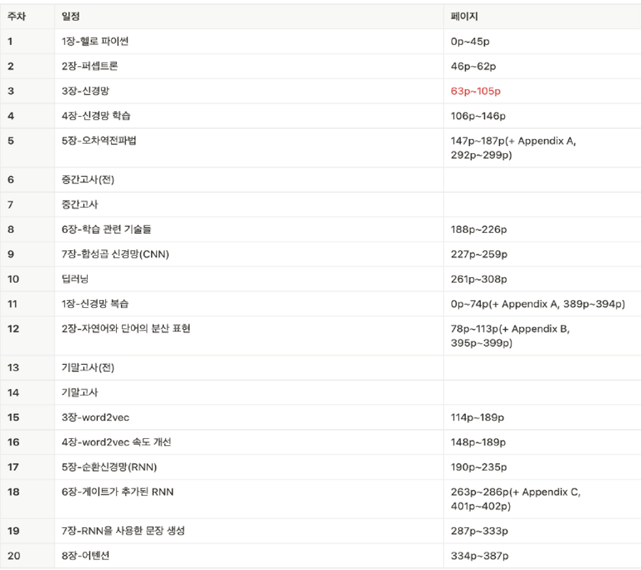

```python
notebook_dp_image('./images/curriculum.png', (900,800))
```

[figure not shown]

```python
notebook_dp_image('./images/W10/1.png', (700,400))
```

```python
import tensorflow as tf
from tensorflow.keras import layers, Input, Model
from tensorflow.keras.datasets import mnist
from tensorflow.keras.utils import to_categorical
from tensorflow.keras.initializers import HeNormal
print(tf.config.list_physical_devices('GPU'))
```

```
[PhysicalDevice(name='/physical_device:GPU:0', device_type='GPU')]
```

```python
(x_train, y_train), (x_test, y_test) = mnist.load_data()
x_train = x_train.astype("float32") / 255.0
x_test = x_test.astype("float32") / 255.0

# 채널위한 차원 추가
x_train = x_train[..., tf.newaxis]
x_test = x_test[..., tf.newaxis]

# one-hot vectors로 변환환
y_train = to_categorical(y_train, num_classes=10)
y_test = to_categorical(y_test, num_classes=10)

x_train.shape, y_train.shape
```

```
((60000, 28, 28, 1), (60000, 10))
```

```python
initializer = HeNormal()

# functional API사용
inputs = Input(shape=(28, 28, 1), name="input_layer")

x = layers.Conv2D(16, (3, 3), activation="relu", name="conv1", kernel_initializer=initializer)(inputs)
x = layers.Conv2D(32, (3, 3), activation="relu", name="conv2", kernel_initializer=initializer)(x)
x = layers.Conv2D(64, (3, 3), activation="relu", name="conv3", kernel_initializer=initializer)(x)
x = layers.MaxPooling2D((2, 2), name="maxpool")(x)
# x = layers.Dropout(0.25, name="dropout1")(x)

x = layers.Flatten(name="flatten")(x)

x = layers.Dense(128, activation="relu", name="affine1", kernel_initializer=initializer)(x)
x = layers.Dropout(0.5, name="dropout1")(x)

x = layers.Dense(128, activation="relu", name="affine2", kernel_initializer=initializer)(x)
x = layers.Dropout(0.5, name="dropout2")(x)

outputs = layers.Dense(10, activation="softmax", name="output_layer", kernel_initializer=initializer)(x)

model = Model(inputs=inputs, outputs=outputs, name="mnist_cnn_functional")

# 모델 컴파일일
model.compile(
    optimizer="adam",
    loss="categorical_crossentropy",
    metrics=["accuracy"]
)

model.summary()
```

```
Model: "mnist_cnn_functional"
```

```
┏━━━━━━━━━━━━━━━━━━━━━━━━━━━━━━━━━┳━━━━━━━━━━━━━━━━━━━━━━━━┳━━━━━━━━━━━━━━━┓
┃ Layer (type)                    ┃ Output Shape           ┃       Param # ┃
┡━━━━━━━━━━━━━━━━━━━━━━━━━━━━━━━━━╇━━━━━━━━━━━━━━━━━━━━━━━━╇━━━━━━━━━━━━━━━┩
│ input_layer (InputLayer)        │ (None, 28, 28, 1)      │             0 │
├─────────────────────────────────┼────────────────────────┼───────────────┤
│ conv1 (Conv2D)                  │ (None, 26, 26, 16)     │           160 │
├─────────────────────────────────┼────────────────────────┼───────────────┤
│ conv2 (Conv2D)                  │ (None, 24, 24, 32)     │         4,640 │
├─────────────────────────────────┼────────────────────────┼───────────────┤
│ conv3 (Conv2D)                  │ (None, 22, 22, 64)     │        18,496 │
├─────────────────────────────────┼────────────────────────┼───────────────┤
│ maxpool (MaxPooling2D)          │ (None, 11, 11, 64)     │             0 │
├─────────────────────────────────┼────────────────────────┼───────────────┤
│ flatten (Flatten)               │ (None, 7744)           │             0 │
├─────────────────────────────────┼────────────────────────┼───────────────┤
│ affine1 (Dense)                 │ (None, 128)            │       991,360 │
├─────────────────────────────────┼────────────────────────┼───────────────┤
│ dropout1 (Dropout)              │ (None, 128)            │             0 │
├─────────────────────────────────┼────────────────────────┼───────────────┤
│ affine2 (Dense)                 │ (None, 128)            │        16,512 │
├─────────────────────────────────┼────────────────────────┼───────────────┤
│ dropout2 (Dropout)              │ (None, 128)            │             0 │
├─────────────────────────────────┼────────────────────────┼───────────────┤
│ output_layer (Dense)            │ (None, 10)             │         1,290 │
└─────────────────────────────────┴────────────────────────┴───────────────┘
```

```
 Total params: 1,032,458 (3.94 MB)
```

```
 Trainable params: 1,032,458 (3.94 MB)
```

```
 Non-trainable params: 0 (0.00 B)
```

```python
# Train the model
model.fit(
    x_train, y_train,
    batch_size=128,
    epochs=12,
    validation_split=0.1
)

# Evaluate on test set
test_loss, test_acc = model.evaluate(x_test, y_test)
print(f"Test accuracy: {test_acc:.4f}")
```

[output not shown]

```
 21/422 ━━━━━━━━━━━━━━━━━━━━ 3s 8ms/step - accuracy: 0.2031 - loss: 2.6664
```

[output not shown]

```
420/422 ━━━━━━━━━━━━━━━━━━━━ 0s 7ms/step - accuracy: 0.6615 - loss: 1.0417
```

[output not shown]

```
422/422 ━━━━━━━━━━━━━━━━━━━━ 0s 12ms/step - accuracy: 0.6622 - loss: 1.0394
```

[output not shown]

```
422/422 ━━━━━━━━━━━━━━━━━━━━ 10s 15ms/step - accuracy: 0.6626 - loss: 1.0383 - val_accuracy: 0.9852 - val_loss: 0.0559
422/422 ━━━━━━━━━━━━━━━━━━━━ 3s 7ms/step - accuracy: 0.9379 - loss: 0.1994 - val_accuracy: 0.9890 - val_loss: 0.0422
422/422 ━━━━━━━━━━━━━━━━━━━━ 3s 8ms/step - accuracy: 0.9556 - loss: 0.1439 - val_accuracy: 0.9883 - val_loss: 0.0441
422/422 ━━━━━━━━━━━━━━━━━━━━ 3s 7ms/step - accuracy: 0.9639 - loss: 0.1142 - val_accuracy: 0.9902 - val_loss: 0.0385
422/422 ━━━━━━━━━━━━━━━━━━━━ 3s 8ms/step - accuracy: 0.9679 - loss: 0.1004 - val_accuracy: 0.9910 - val_loss: 0.0365
422/422 ━━━━━━━━━━━━━━━━━━━━ 3s 8ms/step - accuracy: 0.9718 - loss: 0.0880 - val_accuracy: 0.9925 - val_loss: 0.0352
422/422 ━━━━━━━━━━━━━━━━━━━━ 3s 8ms/step - accuracy: 0.9747 - loss: 0.0800 - val_accuracy: 0.9905 - val_loss: 0.0356
422/422 ━━━━━━━━━━━━━━━━━━━━ 3s 8ms/step - accuracy: 0.9769 - loss: 0.0722 - val_accuracy: 0.9935 - val_loss: 0.0282
422/422 ━━━━━━━━━━━━━━━━━━━━ 3s 8ms/step - accuracy: 0.9794 - loss: 0.0651 - val_accuracy: 0.9922 - val_loss: 0.0343
422/422 ━━━━━━━━━━━━━━━━━━━━ 3s 8ms/step - accuracy: 0.9803 - loss: 0.0573 - val_accuracy: 0.9922 - val_loss: 0.0379
422/422 ━━━━━━━━━━━━━━━━━━━━ 3s 8ms/step - accuracy: 0.9821 - loss: 0.0565 - val_accuracy: 0.9925 - val_loss: 0.0338
422/422 ━━━━━━━━━━━━━━━━━━━━ 3s 7ms/step - accuracy: 0.9829 - loss: 0.0523 - val_accuracy: 0.9912 - val_loss: 0.0384
```

[output not shown]

```
301/313 ━━━━━━━━━━━━━━━━━━━━ 0s 2ms/step - accuracy: 0.9920 - loss: 0.0312
```

[output not shown]

[output not shown]

## 정확도를 더 높이기

1. 앙상블 학습: 여러가지 모델을 같이
2. 학습률 감소: epoch 진행할수록 LR감소시키기
3. 데이터 확장: (data augmentation) 이미 있는 훈련 데이터로 자료 더 만들기 (crop, rotate, zoom, flip, pan)

### 왜 층을 더 깊게 하는가?

CNN의 경우 큰 kernel을 conv.돌리는거보다 작은 kernel을 여러개 돌리는것이 더 효율적이다고 볼 수 있다.

5x5의 kernel을 돌리려면 총 25개의 매개변수를 훈련해야하는데 같은 효과의 3x3필터를 2번 돌리면 총 18개의 매개변수만 훈련해도 되므로 훨씬 더 효율적이다!

인식해야할 포인트들을 층별로 분리를 하면서 학습시의 효율성을 늘린다고 볼 수 있다. 앞 층에서 filtering/condensing을 한 정보를 다음 층이 받아 처리를 하므로 뒤에있는 층들한테는 더 편하고 더 자세한 디테일들을 검출할 수 있음.

## 딥러닝 역사

ILSVRC대회에서의 CNN모델들

초기에는 ML기반으로 이미지의 히스토그램이나 텍스쳐와 직접 추출한 피쳐세트(feeature set)을 사용해서 구분, AlexNet이후 처음으로 DL사용해서 정확도를 크게 높였다~!

#### 대표적 모델들 - VGG

Visual 16레이어와 19레이어 버전이 존재함

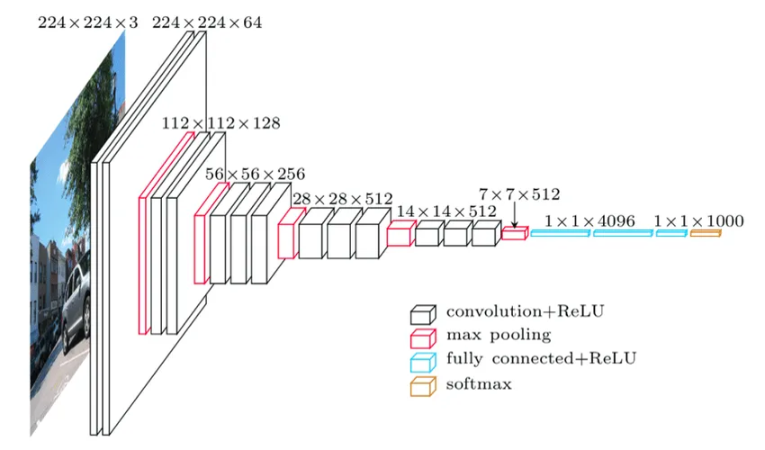

```python
notebook_dp_image('./images/W9/vgg.png', (850,500))
```

#### 대표적 모델들 - GoogLeNet (구글'르'넷)

가장 돋보이는 특징은 inception layer, 여러 convolution을 한방에 해서 마지막에는 다 이어붙여버리는 형식임.

각 convolution kernel별 다양한 특징을 잡아낼 수 있음!

- 1x1: 인풋의 채널 수를 감소시켜 압축해줌
- 3x3: 일반적인 conv.
- 5x5: 3x3보다 큰 디테일을 잡아주는 역할할
- maxpool: 원본 인풋 앞축본 전달역할

또, 중간에 2번 auxiliary ouput, 즉 보조 아웃풋 역할하는 가짜(?) 아웃풋이 있음. 훈련때만 사용해서 중간에 역전파가 동시에 될수 있도록 도와줌. grdient vanishing을 해소하는데에 도움을 줌. Inference시에는 제거함.

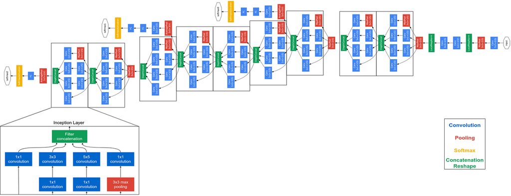

```python
notebook_dp_image('./images/W10/2.png', (1300,500))
```

**Filter concatenation을 살펴보면...**

inception에서의 output을 그냥 순서대로 1차원으로 나열, 나중에 FC(Fully connected)/Dense/Affine 레이어에 바로 사용 가능.

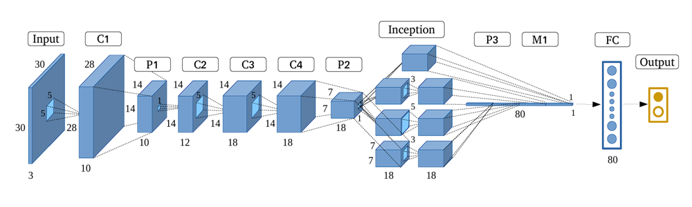

```python
notebook_dp_image('./images/W10/3.png', (1000,300))
```

#### 대표적 모델들 - ResNet

이름인 Residual Network에서 나오듯이, residual이 여기서 나오는 이유는 과거 레이어의 값이 앞에 더해져서 residual(잔여물)이 남기 때문.

skip connection을 통해서 경사/신호가 네트워크가 커질수록 감쇠되는것을 막아줌 (원본을 유지해줌으로서)

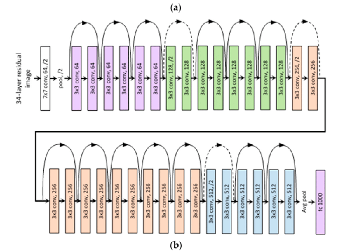

```python
notebook_dp_image('./images/W10/4.png', (700,500))
```

## 딥러닝의 고속화

#### GPU vs CPU?

**TMI.**

GPU는 병렬처리에 최적화, CPU는 몇안되는 코어가 빠르게(3~4Ghz, 높으면 6Ghz이상도) 복잡한 연산을 진행하지만 GPU는 작고 비교적 느린(2Ghz정도) 코어들이 수천에서 수만개 들어있음 + CPU의 작지만 빠른 L1$, L2$에 비해 느리지만 큼지막한 VRAM도 포함 다량의 병렬 도움.

복잡하지 않은 여러개의 연산이 동시에 필요한 합성곱에는 딱맞는 환경~

+ GPU bitrate는 크게 상관 없다는... network의 resiliance때문에 소숫점 좀 차이난다고 성능에 영향은 안줌

## DL의 활용

- **사물검출**: R-CNN서서 ROI검출 이후 그 영역에 대하여 또 이 물체 뭔지 각각 검출 진행 (상자 등 영역 씌우기)
- **분할**: FCN(Fully Conv. Network) 모든 레이어가 Conv.레이어라 최종 출력도 원본이미지와 차원이 같게 함, 최종적으로 역합성곱을 해서 이를 이루어냄 (픽셀단위 구분)
- **사진 캡션**: NIC(Natural Image Caption) 모델을 활용해서 CNN + (LangGen) RNN같이 사용해서 캡션을 더해줌. *지금은 gpt같은 트랜스포머 모델들의 멀티모달 기능때문에 end-to-end로 모델 분리없이 캡션가능*
- **(DC)GAN**: Deep convolutional Generative Adversarial Network

아래의 그림은 두 모델이 경쟁한다는 점에서 "adversarial"이 나온것임

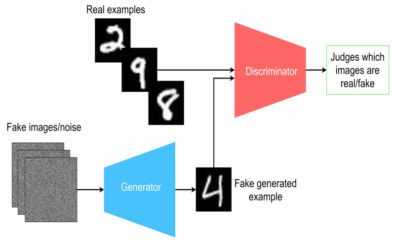

```python
notebook_dp_image('./images/W10/5.jpg', (800,500))
```

- **자율주행**: 앞에 본 R-CNN에 더해서 segmentation이랑 labeling을 통해 카메라에 보이는 환경을 맵핑하는 모델을 사용 (SegNet) [아래 사진은 테슬라꺼](https://www.youtube.com/watch?v=fKXztwtXaGo)

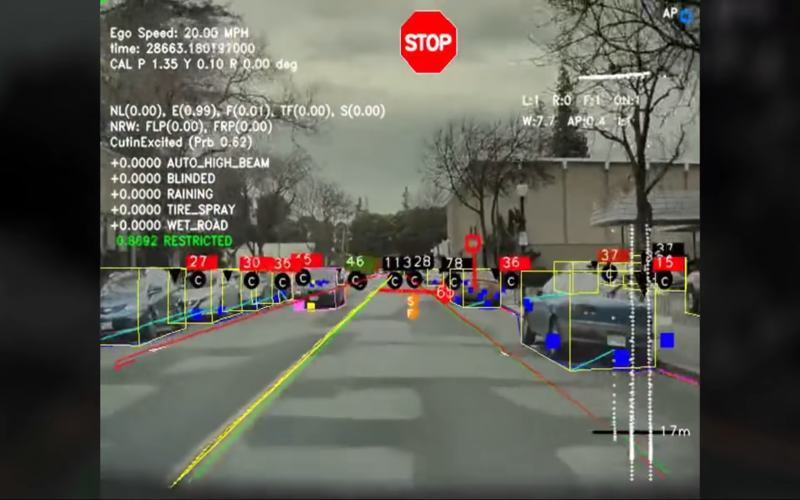

```python
notebook_dp_image('./images/W10/6.png', (800,500))
```

- **강화학습**: DQN(Deep Q Network) 에이전트-환경 사용해서 벨만 방정식을 통해 reward를 얻고 penalty를 피하는 방안으로 훈련을 시킴